# Transformação de escala

Um passo importante de qualquer análise de dados é a uniformização do intervalo de dados, de modo que todas as variáveis do banco de dados tenham o mesmo intervalo de variação.

Seja o exemplo do conjunto de dados aleatório abaixo, são apresentados dois tipos de transformação encontrados na literatura.

```r
# Conjunto de valores aleatórios com média 50 e desvio 15.
(x <- rnorm(100, 50, 15))
```

```
##   [1] 77.30959 51.79985 42.81584 70.32249 50.27563 28.61605 81.53029 27.52701
##   [9] 59.38817 34.18633 23.30217 67.64228 22.76614 65.71886 46.12177 73.93876
##  [17] 26.14196 68.59545 44.31450 26.89818 59.70375 59.95074 12.41262 39.05128
##  [25] 35.25848 49.01506 28.51464 51.62611 40.12803 38.89929 51.03483 36.99815
##  [33] 54.72710 53.81981 29.11970 63.55603 69.75172 56.44921 44.19013 33.92017
##  [41] 49.91829 67.82711 73.00340 60.45281 73.18536 25.34639 52.61042 42.78442
##  [49] 52.81949 43.45018 39.47307 52.72664 62.23968 56.80299 61.88197 46.84799
##  [57] 93.53442 60.06143 18.24795 36.72047 61.77783 55.78383 44.01702 66.36986
##  [65] 45.34364 54.54061 59.57989 26.91958 58.66420 45.79774 40.25471 40.22083
##  [73] 83.68027 77.39994 39.60756 53.71424 77.38733 33.26770 69.06200 49.94108
##  [81] 46.25556 72.61186 47.74581 29.80889 39.61468 44.99607 58.63855 42.40775
##  [89] 41.55603 48.65168 59.68471 47.85778 48.30859 44.30192 42.76871 64.47310
##  [97] 54.28156 25.98592 48.19454 62.06699
```

```r
summary(x)
```

```
##    Min. 1st Qu.  Median    Mean 3rd Qu.    Max.
##   12.41   40.00   49.47   50.21   60.16   93.53
```

## Normalização [0,1]

A normalização transforma os dados no intervalo entre 0 e 1.

```r
x_norm <- (x - min(x)) / (max(x) - min(x))
summary(x_norm)
```

```
##    Min. 1st Qu.  Median    Mean 3rd Qu.    Max.
##  0.0000  0.3401  0.4568  0.4659  0.5886  1.0000
```

## Padronizar [-3,3]

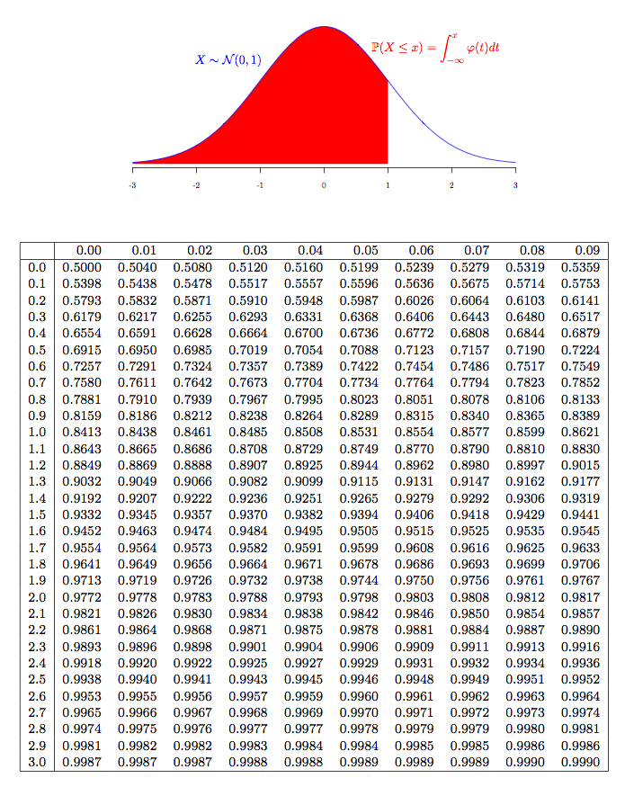

Tabela z-padrão

```r
x_pad <- (x - mean(x)) / sd(x)
summary(x_pad)
```

```
##     Min.  1st Qu.   Median     Mean  3rd Qu.     Max.
## -2.38483 -0.64413 -0.04678  0.00000  0.62790  2.73381
```

```r
## OLHANDO A TABELA
#z = 1,0 ----> p(z) = 0,1587
1 - 2 * 0.1587
```

```
## [1] 0.6826
```

```r
#z = 2,0 ----> p(z) = 0,0228
1 - 2 * 0.0228
```

```
## [1] 0.9544
```

```r
# p(z) = 95% -----> z(p = 0,025) = ?
1.96
```

```
## [1] 1.96
```

```r
# p(z) = 99% -----> z =??
2.575
```

```
## [1] 2.575
```

# Funções do R

## Números aleatórios

### Uniformemente distribuídos

Função: `runif(n, min, max)`

```r
runif(10)
```

```
##  [1] 0.2875959 0.4179466 0.2173612 0.9689908 0.9800405 0.9951321 0.6098396
##  [8] 0.6384581 0.9131233 0.3310675
```

```r
runif(10, 100, 150)
```

```
##  [1] 135.4036 131.9243 104.8712 144.5616 107.7570 120.5139 103.7402 106.1792
##  [9] 127.3846 112.0425
```

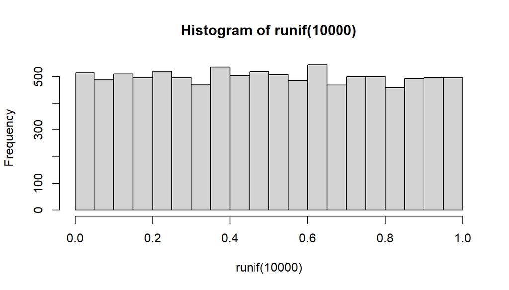

```r
hist(runif(10000))
```

### Normalmente distribuídos

Função: `rnorm(n, mean, sd)`

```r
rnorm(10)
```

```
##  [1]  0.7040298 -1.2839948  1.6138404  1.0038021 -0.1919775 -1.1239885
##  [7] -0.9533027 -0.2265654 -1.5465812 -0.1717750
```

```r
rnorm(10, 100, 15)
```

```
##  [1] 119.68188  99.22661  92.19636  90.60958  87.32454 135.11536 117.36401
##  [8] 126.80614 109.36632 104.83376
```

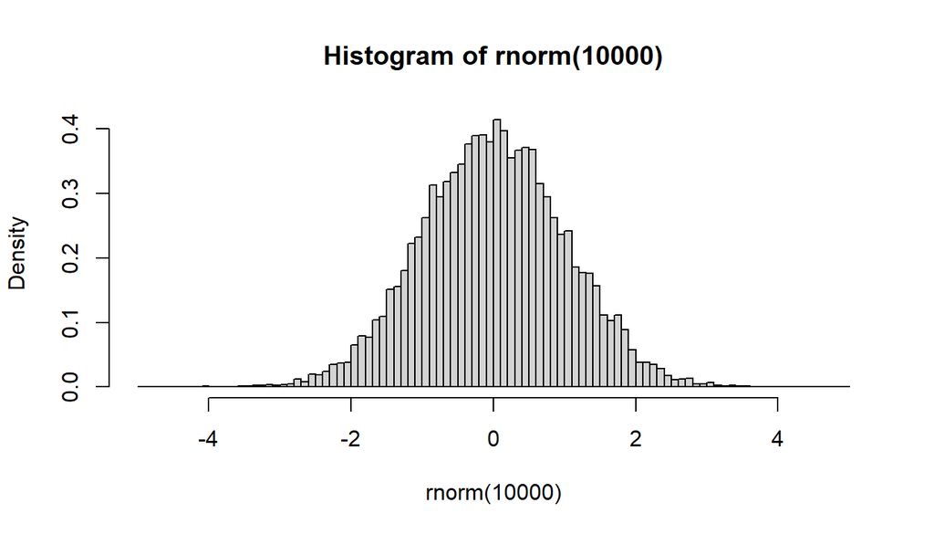

```r
hist(rnorm(10000), breaks = seq(-5,5,.1),
     freq = FALSE)
```

## Distribuição Normal

Encontrando o valor z-padrão com a função `qnorm(area da curva, mean=0, sd=1)`

```
- Unicaudal a esquerda: `z_alpha = qnorm(alpha)`
- Unicaudal a direita: `z_alpha = qnorm(1 - alpha)`
- Bicaudal: `z_alpha/2 = qnorm(1 - alpha/2)`
```

```r
qnorm(.90)
```

```
## [1] 1.281552
```

```r
qnorm(.5)
```

```
## [1] 0
```

Encontrando o p-valor com a função `pnorm(valor z, mean=0, sd=1)`

```
- Unicaudal a esquerda: `p-value = pnorm(z, lower.tail=TRUE)`
- Unicaudal a direita: `p-value = pnorm(z, lower.tail=FALSE)`
- Bicaudal: `p-value = 2 * pnorm(abs(z), lower.tail=FALSE)`
```

```r
pnorm(1.96)
```

```
## [1] 0.9750021
```

```r
pnorm(1.96, lower.tail = FALSE)
```

```
## [1] 0.0249979
```

```r
pnorm(0)
```

```
## [1] 0.5
```

Encontrando a densidade do valor com a função `dnorm(valor z, mean=0, sd=1)`

```r
dnorm(1.96)
```

```
## [1] 0.05844094
```

```r
dnorm(-1.96)
```

```
## [1] 0.05844094
```

```r
dnorm(0)
```

```
## [1] 0.3989423
```

# EXEMPLO 1

```r
## P(z > 1,65)
pnorm(1.65, lower.tail = FALSE)
```

```
## [1] 0.04947147
```

```r
## P(z < 1,65)
pnorm(1.65)
```

```
## [1] 0.9505285
```

```r
## P(1,40 < z < 1,70)
pnorm(1.7) - pnorm(1.4)
```

```
## [1] 0.0361912
```

# EXEMPLO 2

```r
x = c(58,78,84,90,97,70,
      90,86,82,59,90,70,
      74,83,90,75,88,84,
      68,96,70,94,70,110,
      67,68,75,80,68,82,
      104,92,112,84,98,80)


## Análise descritiva
summary(x)
```

```
##    Min. 1st Qu.  Median    Mean 3rd Qu.    Max.
##   58.00   70.00   82.50   82.39   90.00  112.00
```

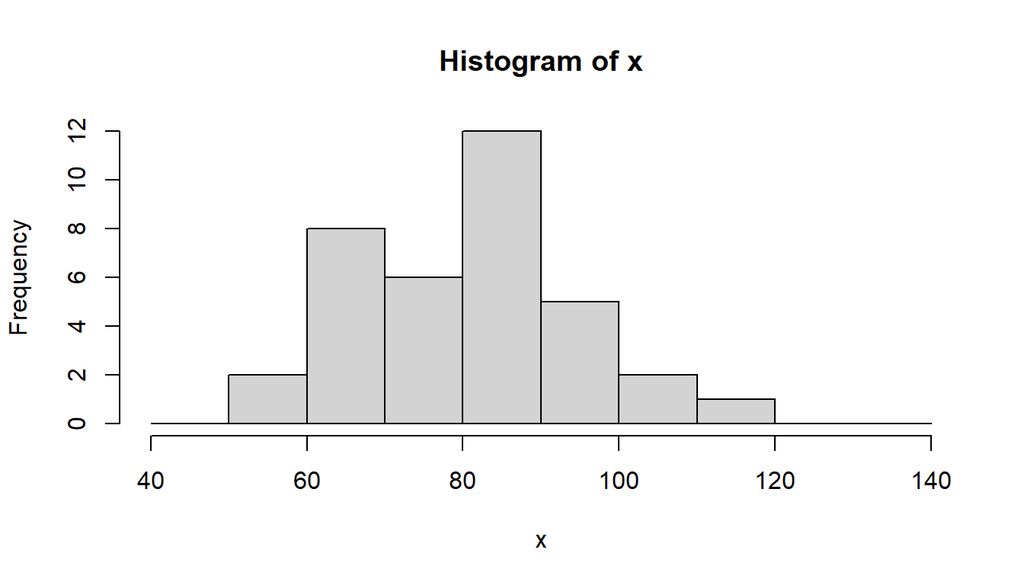

```r
hdados <- hist(x,
               breaks = seq(40,140,10))
```

```r
hdados$breaks
```

```
##  [1]  40  50  60  70  80  90 100 110 120 130 140
```

```r
hdados$counts
```

```
##  [1]  0  2  8  6 12  5  2  1  0  0
```

```r
hdados$density
```

```
##  [1] 0.000000000 0.005555556 0.022222222 0.016666667 0.033333333 0.013888889
##  [7] 0.005555556 0.002777778 0.000000000 0.000000000
```

O parâmetro `density` traz a razão entre a porcentagem de elementos e o intervalo de bins, tanto que a soma das porcentagens `density` é igual a 0.1. Ao multiplicar cada densidade pelo intervalo do bin, a porcentagem total será de 100%.

```r
sum(hdados$density)
```

```
## [1] 0.1
```

```r
sum(hdados$density) * 10
```

```
## [1] 1
```

# Testes do R

## Qui-quadrado (chisq)

Teste de aderência de Qui-quadrado é usado para comparar distribuições observadas com distribuições esperadas em dados discretos (histograma de frequências).

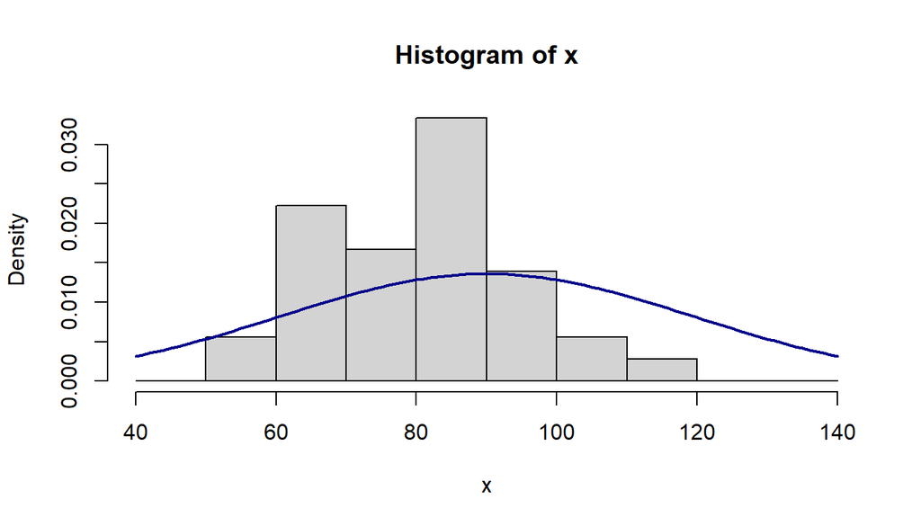

```r
#x_pad <- (x - mean(x))/sd(x)

## Densidade dos valores X com a curva normal teórica
bin <- 10
hist.real <- hist(x, breaks = seq(40,140,bin), freq=FALSE)
curve(dnorm(x, mean(x), sd(x)), col='darkblue', lw=2, add=TRUE)
```

```r
hist.real$density
```

```
##  [1] 0.000000000 0.005555556 0.022222222 0.016666667 0.033333333 0.013888889
##  [7] 0.005555556 0.002777778 0.000000000 0.000000000
```

```r
hist.real$counts
```

```
##  [1]  0  2  8  6 12  5  2  1  0  0
```

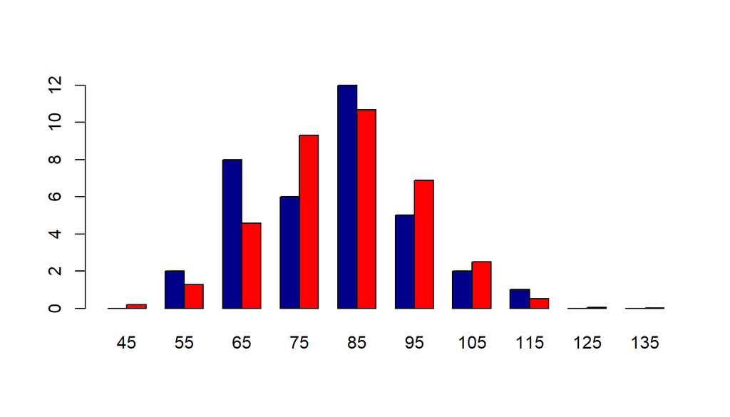

```r
## Frequências das distribuições observadas e esperadas
barplot(rbind(hist.real$counts, dnorm(hist.real$mids, mean(x), sd(x))*bin*length(x) ),
        names.arg = hist.real$mids,
        col = c("darkblue", "red"),
        beside = TRUE
)
```

```r
res <- chisq.test(hist.real$counts, # Frequência observada - dados originais
           p = dnorm(hist.real$mids, mean(x), sd(x))*bin, # Frequência teórica - distribuição normal
           rescale.p = TRUE )
```

## Kolmogorv-Smirnov (KS)

```r
ks.test(x, "pnorm", mean(x), sd(x))
```

```
##
##  One-sample Kolmogorov-Smirnov test
##
## data:  x
## D = 0.10407, p-value = 0.8304
## alternative hypothesis: two-sided
```

```r
ks.test(x_pad, "pnorm")
```

```
##
##  One-sample Kolmogorov-Smirnov test
##
## data:  x_pad
## D = 0.04098, p-value = 0.9961
## alternative hypothesis: two-sided
```

## Shapiro-Wilk

```r
shapiro.test(x)
```

```
##
##  Shapiro-Wilk normality test
##
## data:  x
## W = 0.97612, p-value = 0.6139
```